# QPot: An R Package for Stochastic Differential Equation Quasi-Potential Analysis

Christopher M. Moore

Department of Biology, Case Western Reserve University

Christopher R. Stieha

Department of Biology, Case Western Reserve University

Ben C. Nolting

Department of Biology, Case Western Reserve University

Maria K. Cameron

Department of Mathematics, University of Maryland

Karen C. Abbott

Department of Biology, Case Western Reserve University

2016-09-09

Abstract

QPot (pronounced $ky\overline{\textbf{o}o} + p\ddot{a}t$) is an R package for analyzing two-dimensional systems of stochastic differential equations. It provides users with a wide range of tools to simulate, analyze, and visualize the dynamics of these systems. One of *QPot’s* key features is the computation of the quasi-potential, an important tool for studying stochastic systems. Quasi-potentials are particularly useful for comparing the relative stabilities of equilibria in systems with alternative stable states. This paper describes *QPot*’s primary functions, and explains how quasi-potentials can yield insights about the dynamics of stochastic systems. Three worked examples guide users through the application of *QPot*’s functions.

# Introduction

Differential equations are an important modeling tool in virtually every scientific discipline. Most differential equation models are deterministic, meaning that they provide a set of rules for how variables change over time, and no randomness comes into play. Reality, of course, is filled with random events (i.e., noise or stochasticity). Unfortunately, many of the analytic techniques developed for deterministic ordinary differential equations are insufficient to study stochastic systems, where phenomena like noise-induced transitions between alternative stable states and metastability can occur. For systems subject to stochasticity, the quasi-potential is a tool that yields information about properties such as the expected time to escape a basin of attraction, the expected frequency of transitions between basins, and the stationary probability distribution. [*QPot*](https://CRAN.R-project.org/package=QPot) [abbreviation of Quasi-Potential; Moore et al. (2016)] is an R package that allows users to calculate quasi-potentials, and this paper is a tutorial of its application. This package is intended for use by any researchers who are interested in understanding how stochasticity impacts differential equation models. *QPot* makes quasi-potential analysis accessible to a broad range of modelers, including those who have not previously encountered the topic. The key functions in package *QPot* are listed in Table 1.

Table 1: Key functions in package *QPot*.

[output not shown]

# Adding stochasticity to deterministic models

Consider a differential equation model of the form
$$\label{Deterministic}
\begin{gathered}
\frac{dx}{dt}=f_{1}\left(x(t),y(t)\right) \\
\frac{dy}{dt}=f_{2}\left(x(t),y(t)\right).
\end{gathered} (\#eq:Deterministic)$$
In many cases, state variables are subject to continuous random perturbations, which are commonly modeled as white noise processes. To incorporate these random influences, the original system of deterministic differential equations can be transformed into a system of stochastic differential equations:
$$\label{Stochastic}
\begin{gathered}
dX(t)=f_{1}\left(X(t),Y(t)\right)\, dt+\sigma\, dW_{1}(t)\\
dY(t)=f_{2}\left(X(t),Y(t)\right)\, dt+\sigma\, dW_{2}(t).
\end{gathered} (\#eq:Stochastic)$$
$X$ and $Y$ are now stochastic processes (a change emphasized through the use of capitalization); this means that, at every time $t$, $X(t)$ and $Y(t)$ are random variables, as opposed to real numbers. $\sigma\geq0$ is a parameter specifying the noise intensity, and $W_{1}(t)$ and $W_{2}(t)$ are Wiener processes. A Wiener process is a special type of continuous-time stochastic process whose changes over non-overlapping time intervals, $\Delta t_{1}$ and $\Delta t_{2}$, are independent Gaussian random variables with means zero and standard deviations $\sqrt{\Delta t_{1}}$ and $\sqrt{\Delta t_{2}}$, respectively. The differential notation in equations @ref(eq:Stochastic) is a formal way of representing a set of stochastic integral equations, which must be used because realizations of Wiener processes are not differentiable (to be precise, with probability one, a realization of a Wiener process will be almost nowhere differentiable). The functions $f_{1}$ and $f_{2}$ are called the deterministic skeleton. The deterministic skeleton can be viewed as a vector field that determines the dynamics of trajectories in the absence of stochastic effects. We will forgo a complete overview of stochastic differential equations here; interested readers are encouraged to seek out texts like (Allen 2007) and (Iacus 2009). We note that throughout this paper we use the Itô formulation of stochastic differential equations.

# The quasi-potential

Consider System @ref(eq:Stochastic), with deterministic skeleton @ref(eq:Deterministic). If there exists a function $V(x,y)$ such that $f_{1}(x,y)=-\frac{\partial V}{\partial x}$ and $f_{2}(x,y)=-\frac{\partial V}{\partial y}$, then System @ref(eq:Deterministic) is called a gradient system and $V(x,y)$ is called the system’s potential function. The dynamics of a gradient system can be visualized by considering the $\left(x,y\right)$-coordinates of a ball rolling on a surface specified by $z=V(x,y)$. Gravity causes the ball to roll downhill, and stable equilibria correspond to the bottoms of the surface’s valleys. $V(x,y)$ is a Lyapunov function for the system, which means that if $\left(x(t),\, y(t)\right)$ is a solution to System @ref(eq:Deterministic), then $\frac{d}{dt}\left(V\left(x(t),\, y(t)\right)\right)\leq0$, and the only places that $\frac{d}{dt}\left(V\left(x(t),\, y(t)\right)\right)=0$ are at equilibria. This means that the ball’s elevation will monotonically decrease, and will only be constant if the ball is at an equilibrium. The basin of attraction of a stable equilibrium $\mathbf{e}^{*}$ of System @ref(eq:Deterministic) is the set of points that lie on solutions that asymptotically approach $\mathbf{e}^{*}$.

The potential function is useful for understanding the stochastic System @ref(eq:Stochastic). As in the deterministic case, the dynamics of the stochastic system can be represented by a ball rolling on the surface $z=V(x,y)$; in the stochastic system, however, the ball experiences random perturbations due to noise terms in the System @ref(eq:Stochastic). In systems with multiple stable equilibria, these random perturbations can cause a trajectory to move between different basins of attraction. The depth of the potential (that is, the difference in $V$ at the equilibrium and the lowest point on the boundary of its basin of attraction), is a useful measure of the stability of the equilibrium (see Nolting and Abbott 2016). The deeper the potential, the less likely it will be for stochastic perturbations to cause an escape from the basin of attraction. This relationship between the potential and the expected time to escape from a basin of attraction can be made precise (see formulae in the appendices of Nolting and Abbott 2016). Similarly, the potential function is directly related to the expected frequency of transitions between different basins, and to the stationary probability distribution of System @ref(eq:Stochastic).

Unfortunately, gradient systems are very special, and a generic system of the form @ref(eq:Deterministic) will almost certainly not be a gradient system. That is, there will be no function $V(x,y)$ that satisfies $f_{1}(x,y)=-\frac{\partial V}{\partial x}$ and $f_{2}(x,y)=-\frac{\partial V}{\partial y}$.

Fortunately, quasi-potential functions generalize the concept of a potential function for use in non-gradient systems. A non-gradient system’s quasi-potential, $\Phi(x,y)$, possesses many of the properties of a gradient system’s potential function; in particular, a non-gradient system’s quasi-potential is related to its stationary probability distribution in the same way that a gradient system’s potential function is related to its stationary probability distribution. Furthermore, $\Phi(x,y)$ is a Lyapunov function for the deterministic skeleton of a non-gradient system, just as a potential function is for a gradient system. Therefore, the surface $z=\Phi(x,y)$ is a highly useful stability metric. The quasi-potential also provides information about the expected frequency of transitions between basins of attraction and the expected time required to escape each basin.

The mathematical definition of the quasi-potential is rather involved. We refer readers to Cameron (2012), Nolting and Abbott (2016), and the references therein for the technical construction.

In both this paper and in package *QPot*, the function that we refer to as the quasi-potential is $\frac{1}{2}$ times the quasi-potential as defined by Freidlin and Wentzell (2012). This choice is made so that the quasi-potential will agree with the potential in gradient systems.

*QPot* is an R package that contains tools for calculating and analyzing quasi-potentials (which, for the special case of gradient systems, are simply potentials). The following three examples show how to use the tools in this package. The first example is a simple consumer-resource model from ecology. This example is explained in detail, starting with the analysis of the deterministic skeleton, proceeding with simulation of the stochastic system, and finally demonstrating the calculation, analysis, and interpretation of the quasi-potential. The second and third examples are covered in less detail, but illustrate some special system behaviors. Systems with limit cycles, like Example 2, require a slightly different procedure than systems that only have point attractors. Extra care must be taken constructing global quasi-potentials for exotic systems, like Example 3.

# Example 1: A consumer-resource model with alternative stable states

Consider the stochastic version (*sensu* @ref(eq:Stochastic)) of a standard consumer-resource model of plankton ($X$) and their consumers ($Y$) (Collie and Spencer 1994; Steele and Henderson 1981):
$$\label{ex1}
\begin{split}
dX(t)&=\left(\alpha
X(t)\left(1-\frac{X(t)}{\beta}\right)-\frac{\delta\, X(t)^{2}\,
Y(t)}{\kappa+X(t)^{2}}\right)\, dt+\sigma\, dW_{1}(t)\\
dY(t)&=\left(\frac{\gamma\, X(t)^{2}\, Y(t)}{\kappa+X(t)^{2}}-\mu\,
Y(t)^{2}\right)\, dt+\sigma\, dW_{2}(t).
\end{split} (\#eq:ex1)$$
The model is formulated with a Type III functional response; the relationship between the plankton density and the per-capita consumption rate of plankton is sigmoid. $\alpha$ is the plankton’s maximum population growth rate, $\beta$ is the plankton carrying capacity, $\delta$ is the maximal feeding rate of the consumers, $\gamma$ is the maximum conversion rate of plankton to consumer (which takes into account maximum feeding rate), $\kappa$ controls how quickly the consumption rate saturates, and $\mu$ is the consumer mortality rate. We will analyze this example with a set of parameter values that yield two stables states: $\alpha=1.54$, $\beta=10.14$, $\gamma=0.476$, $\delta=1$, $\kappa=1$, and $\mu=0.112509$.

## Step 1: Analyzing the deterministic skeleton

There are preexisting tools in R for analyzing the deterministic skeleton of System @ref(eq:ex1), which will be described briefly in this subsection. Many of the these tools can be found in the CRAN Task View for Differential Equations (https://CRAN.R-project.org/view=DifferentialEquations), but we use a select few in our analysis. The first step is to find the equilibria for the system and determine their stability with linear stability analysis. Equilibria can be found using the package [*rootSolve*](https://CRAN.R-project.org/package=rootSolve) (Soetaert and Herman 2008). *rootSolve* provides routines that allow users to find roots of nonlinear functions, and perform equilibria and steady-state analysis of ordinary differential equations (ODEs). In Example 1, the equilibria are $\mathbf{e}_{u1}=(0,0)$, $\mathbf{e}_{s1}=(1.4049,\,2.8081)$, $\mathbf{e}_{u2}=(4.2008,\,4.0039)$, $\mathbf{e}_{s2}=(4.9040,\,4.0619)$, and $\mathbf{e}_{u3}=(10.14,\,0)$. Eigenvalues of the linearized system at an equilibrium can be found by using `eigen()` in package *base* over the Jacobian matrix (`jacobian.full()` in package *rootSolve*), which determines the asymptotic stability of the system. $\mathbf{e}_{u1}$ is an unstable source and $\mathbf{e}_{u2}$ and $\mathbf{e}_{u3}$ are saddles. The eigenvalues corresponding to $\mathbf{e}_{s1}$ are $-0.047\pm0.458\, i$ and the eigenvalues corresponding to $\mathbf{e}_{s2}$ are $-0.377$ and $-0.093$. Hence $\mathbf{e}_{s1}$ is a stable spiral point and $\mathbf{e}_{s2}$ is a stable node. To ease transition from packages such as [*deSolve*](https://CRAN.R-project.org/package=deSolve) (Soetaert, Petzoldt, and Setzer 2010) and *rootSolve* to our package *QPot*, we include the wrapper function `Model2String()`, which takes a function containing equations and a list of parameters and their values, and returns the equations in a string that is usable by *QPot* (see the help page for an example).

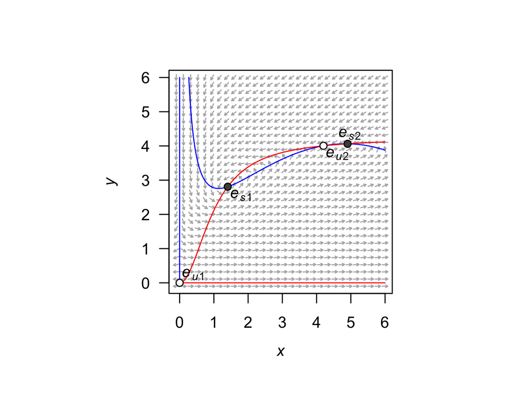

Figure 1: A stream plot of the deterministic skeleton of System @ref(eq:ex1). The blue line is an $x$-nullcline (where $\frac{dx}{dt}=0$) and the red line is a $y$-nullcline (where $\frac{dy}{dt}=0$). Open circles are unstable equilibria and filled circles are stable equilibria. Made using the package *phaseR*.

The package [*phaseR*](https://CRAN.R-project.org/package=phaseR) (Grayling 2014b, 2014a) is an R package for the qualitative analysis of one- and two-dimensional autonomous ODE systems using phase plane methods (including the linear stability analysis described in the preceding paragraph). We use *phaseR* to generate a stream plot of the deterministic skeleton of System @ref(eq:ex1) (Figure 1). Note that a stream plot is a phase plane plot that displays solutions of a system of differential equations; these solutions are also called streamlines. The *deSolve* package can be used to find solutions corresponding to particular initial conditions of the deterministic skeleton of System @ref(eq:ex1). During the analysis of the deterministic skeleton of a system, it is important to note several things. The first is the range of $x$ and $y$ values over which relevant dynamics occur. In Example 1, transitions between the stable equilibria are a primary point of interest, so one might wish to focus on a region like the one displayed in Figure 1, even though this region excludes $\mathbf{e}_{u3}$. The regions of phase space that the user finds interesting will determine the window sizes and ranges used later in the quasi-potential calculations. Second, it is important to note if there are any limit cycles. If there are, it will be necessary to identify a point on the limit cycle. This can be accomplished by calculating a long-time solution of the system of ODEs to obtain a trajectory that settles down on the limit cycle (see Example 2). Finally, it is important to note regions of phase space that correspond to unbounded solutions. As explained in subsequent sections, it is worth examining system behavior in negative phase space, even in cases where negative quantities lack physical meaning.